# Normalized average error difference (NAED) comparisons for eJAB

eJAB clinical-trials project

September 24, 2026

# Comparisons

This R Markdown file is the single source for four normalized average error difference (NAED) comparisons:

1. $eJAB_{01}\leq1$ versus $p<0.005$, for all 10 tests.
2. $eJAB_{01}\leq1$ versus $p<0.05$, for all 10 tests.
3. $eJAB_{01}\leq1$ versus $BF_{01}^{BIC}\leq1$, for the six tests with an explicit parametric likelihood. Cox regression and the three rank tests are excluded.
4. $eJAB_{01}\leq1$ versus $TSBF_{01}\leq1$, for the $2\times2$, $3\times3$, and $5\times5$ chi-square independence designs.

The TSBF comparison is restricted to these three chi-square independence designs. Its test-statistic Bayes-factor function is transcribed from page 6 of `Bayes_factor_function.pdf`, evaluated at the true standardized effect size, and uses $q=(R-1)(C-1)$ for each table dimension.

# Analysis scope and exclusions

```r
scope <- tribble(
  ~test, ~p_comparison, ~bic_comparison, ~tsbf_comparison, ~tsbf_source,
  "Two-sample t-test", "Included", "Included", "Excluded", NA_character_,
  "Simple linear regression", "Included", "Included", "Excluded", NA_character_,
  "Simple logistic regression", "Included", "Included", "Excluded", NA_character_,
  "Cox proportional-hazards regression", "Included", "Excluded; semiparametric partial likelihood", "Excluded", NA_character_,
  "Wilcoxon signed-rank test", "Included", "Excluded", "Excluded", NA_character_,
  "Mann-Whitney U-test", "Included", "Excluded", "Excluded", NA_character_,
  "One-way ANOVA", "Included", "Included", "Excluded", NA_character_,
  "Repeated-measures ANOVA", "Included", "Included", "Excluded", NA_character_,
  "Chi-square independence test", "Included", "Included", "Included for 2x2, 3x3, and 5x5 designs", "BFF PDF page 6",
  "Kruskal-Wallis test", "Included", "Excluded", "Excluded", NA_character_
)

kable(scope)
```

| test | p_comparison | bic_comparison | tsbf_comparison | tsbf_source |
| --- | --- | --- | --- | --- |
| Two-sample t-test | Included | Included | Excluded | NA |
| Simple linear regression | Included | Included | Excluded | NA |
| Simple logistic regression | Included | Included | Excluded | NA |
| Cox proportional-hazards regression | Included | Excluded; semiparametric partial likelihood | Excluded | NA |
| Wilcoxon signed-rank test | Included | Excluded | Excluded | NA |
| Mann-Whitney U-test | Included | Excluded | Excluded | NA |
| One-way ANOVA | Included | Included | Excluded | NA |
| Repeated-measures ANOVA | Included | Included | Excluded | NA |
| Chi-square independence test | Included | Included | Included for 2x2, 3x3, and 5x5 designs | BFF PDF page 6 |
| Kruskal-Wallis test | Included | Excluded | Excluded | NA |

```r
write.csv(
  scope,
  file.path(output_dir, "comparison_scope_and_exclusions.csv"),
  row.names = FALSE
)
```

Cox regression and the three rank tests are excluded from the BIC comparison, which is restricted to tests with an explicit parametric likelihood. TSBF is evaluated for the 2x2, 3x3, and 5x5 chi-square independence designs.

A simulated replicate is excluded before inspecting any decision-rule result when the fitted model fails, its native test statistic is non-finite, its $p$-value is non-finite or outside $[0,1]$, or its effective sample size is not greater than one. No replicate is excluded because its $p$-value, test statistic, effect size, eJAB, BIC BF, or TSBF is unusually large or small.

# eJAB and BIC functions

For eJAB, a test with $q$ tested degrees of freedom maps its reported two-sided or right-tail $p$-value to

$$W=F^{-1}_{\chi_q^2}(1-p).$$

The eJAB approximation is

$$eJAB_{01}=\sqrt{n_{\mathrm{eff}}}
\exp\left[-\frac12(1-n_{\mathrm{eff}}^{-1/q})W\right]$$

For the BIC comparison, let $\Lambda=2\{\ell(\widehat\theta_1)-\ell(\widehat\theta_0)\}$ be the likelihood-ratio statistic calculated directly from the fitted alternative and null models. The BIC Bayes-factor approximation is

$$BF_{01}^{BIC}=n_{\mathrm{eff}}^{q/2}\exp(-\Lambda/2).$$

Thus, the BIC decision does not substitute an asymptotic chi-square quantile for the fitted-model likelihood ratio.

```r
clip_p <- function(p) {
  pmin(pmax(p, .Machine$double.xmin), 1 - .Machine$double.eps)
}

ejab01 <- function(p, n_eff, q) {
  W <- qchisq(clip_p(p), df = q, lower.tail = FALSE)
  sqrt(n_eff) * exp(-0.5 * (1 - n_eff^(-1 / q)) * W)
}

bic_bf01_from_lr <- function(lr_statistic, n_eff, q) {
  n_eff^(q / 2) * exp(-pmax(lr_statistic, 0) / 2)
}
```

# Test-statistic Bayes-factor functions

The following functions transcribe the seven BFFs from `Bayes_factor_function.pdf`. The PDF reports $BFF_{10}$; the analysis uses $TSBF_{01}=1/BFF_{10}$.

```r
bff10_t <- function(t, nu, tau2) {
  r <- 1 + t^2 / nu
  u <- 1 + t^2 / (nu * (1 + tau2))
  k <- tau2 * (nu + 1) / (nu * (1 + tau2))
  exp(
    -1.5 * log1p(tau2) +
      ((nu + 1) / 2) * (log(r) - log(u)) +
      log1p(k * t^2 / u)
  )
}

bff10_z <- function(z, tau2) {
  exp(
    -1.5 * log1p(tau2) +
      log1p(tau2 * z^2 / (1 + tau2)) +
      tau2 * z^2 / (2 * (1 + tau2))
  )
}

bff10_anova <- function(F_stat, groups, n_total, tau2) {
  v <- (n_total - groups) * (1 + tau2)
  exp(
    -((groups + 1) / 2) * log1p(tau2) +
      ((n_total - 1) / 2) *
        (log1p((groups - 1) * F_stat / (n_total - groups)) -
           log1p((groups - 1) * F_stat / v)) +
      log1p((n_total - 1) * tau2 * F_stat /
              (v + (groups - 1) * F_stat))
  )
}

bff10_ranova <- function(F_stat, conditions, subjects, tau2) {
  u <- (subjects - 1) * (1 + tau2)
  exp(
    -((conditions + 1) / 2) * log1p(tau2) +
      (((conditions - 1) * subjects) / 2) *
        (log1p(F_stat / (subjects - 1)) - log1p(F_stat / u)) +
      log1p(subjects * tau2 * F_stat / (u + F_stat))
  )
}

bff10_chisq <- function(chisq_stat, q, tau2) {
  exp(
    -(q / 2 + 1) * log1p(tau2) +
      log1p(tau2 * chisq_stat / (q * (1 + tau2))) +
      tau2 * chisq_stat / (2 * (1 + tau2))
  )
}

bff10_cox <- function(lambda, tau2) {
  bff10_z(sqrt(pmax(lambda, 0)), tau2)
}

yuan_johnson_normal_bf01 <- function(T_star) {
  sqrt(2) * exp(-T_star^2 / 4)
}

yuan_johnson_kw_bf01 <- function(W, groups, tau = 1) {
  q <- groups - 1
  (1 + tau)^(q / 2) * exp(-tau * W / (2 * (1 + tau)))
}

stopifnot(
  all.equal(bff10_t(2, 28, 0), 1),
  all.equal(bff10_z(2, 0), 1),
  all.equal(bff10_anova(2, 4, 40, 0), 1),
  all.equal(bff10_ranova(2, 4, 20, 0), 1),
  all.equal(bff10_chisq(5, 4, 0), 1),
  all.equal(bff10_cox(4, 0), 1),
  all.equal(yuan_johnson_normal_bf01(0), sqrt(2)),
  all.equal(yuan_johnson_kw_bf01(0, 5), 4)
)
```

# Simulation models

All tests use their native row-level statistic. The three rank tests use heavy-tailed $t_3$ errors with variance one, matching the earlier simulation.

```r
test_labels <- c(
  ttest = "Two-sample t-test",
  lm = "Linear regression",
  logistic = "Logistic regression",
  cox = "Cox PH regression",
  wilcoxon = "Wilcoxon signed-rank",
  mannwhitney = "Mann-Whitney",
  anova = "One-way ANOVA",
  ranova = "Repeated-measures ANOVA",
  chisq = "Chi-square independence",
  kruskal = "Kruskal-Wallis"
)

q_by_test <- c(
  ttest = 1L, lm = 1L, logistic = 1L, cox = 1L,
  wilcoxon = 1L, mannwhitney = 1L,
  anova = 3L, ranova = 3L, chisq = 4L, kruskal = 4L
)

bic_test_keys <- c(
  "ttest", "lm", "logistic",
  "anova", "ranova", "chisq"
)
tsbf_test_keys <- "chisq"

contrast_scores <- function(k) {
  x <- seq_len(k) - (k + 1) / 2
  x / sqrt(mean(x^2))
}

chisq_probabilities <- function(theta) {
  log_p <- matrix(0, 3, 3)
  diag(log_p) <- theta
  p <- exp(log_p)
  p / sum(p)
}

chisq_omega2 <- function(theta) {
  p <- chisq_probabilities(theta)
  expected <- outer(rowSums(p), colSums(p))
  sum((p - expected)^2 / expected)
}

chisq_tau2 <- function(n, omega2, q) {
  n * omega2 / q
}

tau2_for <- function(test_key, n, theta, simulation_result = NULL) {
  if (test_key == "ttest") {
    n1 <- floor(n / 2)
    n2 <- n - n1
    return(theta^2 / (2 * (1 / n1 + 1 / n2)))
  }
  if (test_key == "lm") return(n * theta^2 / 2)
  if (test_key == "logistic") return(n * (theta / 2)^2 / 2)
  if (test_key == "cox") {
    events <- simulation_result$events
    return(theta^2 * events / 4)
  }
  if (test_key == "anova") {
    groups <- 4
    scores <- contrast_scores(groups)
    sizes <- rep(floor(n / groups), groups)
    if (n %% groups > 0) {
      sizes[seq_len(n %% groups)] <- sizes[seq_len(n %% groups)] + 1
    }
    weights <- sizes / sum(sizes)
    means <- theta * scores
    omega2 <- sum(weights * (means - sum(weights * means))^2) / (groups - 1)
    return(n * omega2 / 2)
  }
  if (test_key == "ranova") {
    conditions <- 4
    means <- theta * contrast_scores(conditions)
    omega2 <- sum((means - mean(means))^2) / (conditions - 1)
    return(n * omega2 / 2)
  }
  if (test_key == "chisq") {
    return(chisq_tau2(
      n,
      chisq_omega2(theta),
      unname(q_by_test[test_key])
    ))
  }
  NA_real_
}

simulate_one <- function(test_key, n, theta) {
  tryCatch({
    if (test_key == "ttest") {
      n1 <- floor(n / 2)
      n2 <- n - n1
      nu <- n - 2
      noncentrality <- theta / sqrt(1 / n1 + 1 / n2)
      statistic <- rt(1, nu, ncp = noncentrality)
      return(list(
        statistic = statistic,
        p = 2 * pt(-abs(statistic), nu),
        n_eff = n,
        nu = nu,
        bic_lr = n * log1p(statistic^2 / nu)
      ))
    }

    if (test_key == "lm") {
      nu <- n - 2
      centered_x_ss <- rchisq(1, n - 1)
      statistic <- rt(
        1, nu,
        ncp = theta * sqrt(centered_x_ss)
      )
      return(list(
        statistic = statistic,
        p = 2 * pt(-abs(statistic), nu),
        n_eff = n,
        nu = nu,
        bic_lr = n * log1p(statistic^2 / nu)
      ))
    }

    if (test_key == "logistic") {
      # A balanced binary predictor makes the two binomial group counts exact
      # sufficient statistics. This evaluates the same parametric likelihood
      # without allocating an n-row dataset at sample sizes up to 10^7.
      sizes <- c(floor(n / 2), n - floor(n / 2))
      probabilities <- plogis(c(-theta / 2, theta / 2))
      successes <- rbinom(2, sizes, probabilities)
      fitted_probabilities <- successes / sizes
      pooled_probability <- sum(successes) / n
      full_loglik <- sum(dbinom(
        successes, sizes, fitted_probabilities, log = TRUE
      ))
      null_loglik <- sum(dbinom(
        successes, sizes, pooled_probability, log = TRUE
      ))
      likelihood_ratio <- pmax(2 * (full_loglik - null_loglik), 0)
      return(list(
        statistic = sqrt(likelihood_ratio),
        p = pchisq(likelihood_ratio, 1, lower.tail = FALSE),
        n_eff = n,
        bic_lr = likelihood_ratio
      ))
    }

    if (test_key == "cox") {
      x <- sample(rep(c(0, 1), length.out = n))
      event_time <- rexp(n, rate = 0.1 * exp(theta * x))
      censor_time <- rexp(n, rate = 0.025)
      time <- pmin(event_time, censor_time)
      event <- as.integer(event_time <= censor_time)
      fit <- suppressWarnings(coxph(
        Surv(time, event) ~ x,
        ties = "efron",
        control = coxph.control(iter.max = 30)
      ))
      lambda <- pmax(unname(2 * diff(fit$loglik)), 0)
      events <- sum(event)
      return(list(
        statistic = lambda,
        p = pchisq(lambda, 1, lower.tail = FALSE),
        n_eff = events,
        events = events,
        bic_lr = lambda
      ))
    }

    if (test_key == "wilcoxon") {
      d <- theta + rt(n, 3) / sqrt(3)
      ranks <- rank(abs(d), ties.method = "average")
      T_stat <- sum(ranks[d > 0])
      mean0 <- n * (n + 1) / 4
      sd0 <- sqrt(n * (n + 1) * (2 * n + 1) / 24)
      T_star <- (T_stat - mean0) / sd0
      return(list(
        statistic = T_star,
        p = 2 * pnorm(-abs(T_star)),
        n_eff = n,
        bic_lr = NA_real_
      ))
    }

    if (test_key == "mannwhitney") {
      n1 <- floor(n / 2)
      n2 <- n - n1
      x <- rt(n1, 3) / sqrt(3)
      y <- theta + rt(n2, 3) / sqrt(3)
      combined_ranks <- rank(c(x, y), ties.method = "average")
      T_stat <- sum(combined_ranks[seq_len(n1)])
      mean0 <- n1 * (n + 1) / 2
      sd0 <- sqrt(n1 * n2 * (n + 1) / 12)
      T_star <- (T_stat - mean0) / sd0
      return(list(
        statistic = T_star,
        p = 2 * pnorm(-abs(T_star)),
        n_eff = n,
        bic_lr = NA_real_
      ))
    }

    if (test_key == "anova") {
      groups <- 4
      sizes <- rep(floor(n / groups), groups)
      if (n %% groups > 0) {
        sizes[seq_len(n %% groups)] <- sizes[seq_len(n %% groups)] + 1
      }
      means <- theta * contrast_scores(groups)
      weighted_mean <- sum(sizes * means) / n
      noncentrality <- sum(sizes * (means - weighted_mean)^2)
      df1 <- groups - 1
      df2 <- n - groups
      statistic <- rf(1, df1, df2, ncp = noncentrality)
      return(list(
        statistic = statistic,
        p = pf(statistic, df1, df2, lower.tail = FALSE),
        n_eff = n,
        bic_lr = n * log1p(df1 * statistic / df2)
      ))
    }

    if (test_key == "ranova") {
      conditions <- 4
      means <- theta * contrast_scores(conditions)
      df1 <- conditions - 1
      df2 <- (conditions - 1) * (n - 1)
      noncentrality <- n * sum((means - mean(means))^2)
      statistic <- rf(1, df1, df2, ncp = noncentrality)
      return(list(
        statistic = statistic,
        p = pf(statistic, df1, df2, lower.tail = FALSE),
        n_eff = n * (conditions - 1),
        bic_lr = n * conditions * log1p(df1 * statistic / df2)
      ))
    }

    if (test_key == "chisq") {
      counts <- matrix(
        rmultinom(1, n, as.vector(chisq_probabilities(theta))),
        3, 3
      )
      fit <- suppressWarnings(chisq.test(counts, correct = FALSE))
      statistic <- unname(fit$statistic)
      positive <- counts > 0 & fit$expected > 0
      likelihood_ratio <- 2 * sum(
        counts[positive] * log(counts[positive] / fit$expected[positive])
      )
      return(list(
        statistic = statistic,
        p = pchisq(statistic, 4, lower.tail = FALSE),
        n_eff = n,
        bic_lr = pmax(likelihood_ratio, 0)
      ))
    }

    if (test_key == "kruskal") {
      groups <- 5
      sizes <- rep(floor(n / groups), groups)
      if (n %% groups > 0) {
        sizes[seq_len(n %% groups)] <- sizes[seq_len(n %% groups)] + 1
      }
      means <- theta * contrast_scores(groups)
      group <- factor(rep(seq_len(groups), sizes))
      y <- rep(means, sizes) + rt(n, 3) / sqrt(3)
      fit <- kruskal.test(y ~ group)
      statistic <- unname(fit$statistic)
      return(list(
        statistic = statistic,
        p = pchisq(statistic, 4, lower.tail = FALSE),
        n_eff = n,
        bic_lr = NA_real_
      ))
    }

    stop("Unknown test key")
  }, error = function(e) {
    list(
      statistic = NA_real_,
      p = NA_real_,
      n_eff = NA_real_,
      bic_lr = NA_real_
    )
  })
}
```

# Decision rules and average error estimation

```r
valid_result <- function(x, test_key) {
  is.finite(x$statistic) &&
    is.finite(x$p) && x$p >= 0 && x$p <= 1 &&
    is.finite(x$n_eff) && x$n_eff > 1 &&
    (
      !test_key %in% bic_test_keys ||
        (is.finite(x$bic_lr) && x$bic_lr >= 0)
    )
}

tsbf01 <- function(test_key, result, n, theta) {
  if (test_key == "wilcoxon" || test_key == "mannwhitney") {
    return(yuan_johnson_normal_bf01(result$statistic))
  }
  if (test_key == "kruskal") {
    return(yuan_johnson_kw_bf01(result$statistic, groups = 5, tau = 1))
  }

  tau2 <- tau2_for(test_key, n, theta, result)
  bf10 <- switch(
    test_key,
    ttest = bff10_t(result$statistic, result$nu, tau2),
    lm = bff10_t(result$statistic, result$nu, tau2),
    logistic = bff10_z(result$statistic, tau2),
    cox = bff10_cox(result$statistic, tau2),
    anova = bff10_anova(result$statistic, 4, n, tau2),
    ranova = bff10_ranova(result$statistic, 4, n, tau2),
    chisq = bff10_chisq(result$statistic, 4, tau2),
    stop("Unknown test key")
  )
  1 / bf10
}

decisions_for <- function(draws, test_key, n, theta) {
  q <- unname(q_by_test[test_key])
  p <- map_dbl(draws, "p")
  n_eff <- map_dbl(draws, "n_eff")
  ejab <- ejab01(p, n_eff, q)
  bic <- if (test_key %in% bic_test_keys) {
    bic_bf01_from_lr(map_dbl(draws, "bic_lr"), n_eff, q)
  } else {
    rep(NA_real_, length(draws))
  }
  tsbf <- if (test_key %in% tsbf_test_keys) {
    map_dbl(draws, ~ tsbf01(test_key, .x, n, theta))
  } else {
    rep(NA_real_, length(draws))
  }

  tibble(
    reject_p = p < p_threshold,
    reject_ejab = ejab <= bf01_threshold,
    reject_bic = bic <= bf01_threshold,
    reject_tsbf = tsbf <= bf01_threshold
  )
}

simulate_test_n <- function(test_key, n, null_reps, alt_reps, seed,
                            effect_grid = theta_grid) {
  set.seed(seed)

  null_draws <- replicate(
    null_reps,
    simulate_one(test_key, n, 0),
    simplify = FALSE
  )
  null_draws <- null_draws[
    map_lgl(null_draws, valid_result, test_key = test_key)
  ]

  map_dfr(effect_grid, function(theta) {
    alt_draws <- replicate(
      alt_reps,
      simulate_one(test_key, n, theta),
      simplify = FALSE
    )
    alt_draws <- alt_draws[
      map_lgl(alt_draws, valid_result, test_key = test_key)
    ]

    if (!length(null_draws) || !length(alt_draws)) {
      return(tibble(
        test_key = test_key,
        test = unname(test_labels[test_key]),
        n = n,
        theta = theta,
        null_valid_reps = length(null_draws),
        alt_valid_reps = length(alt_draws)
      ))
    }

    null_decisions <- decisions_for(null_draws, test_key, n, theta)
    alt_decisions <- decisions_for(alt_draws, test_key, n, theta)

    alpha_p <- mean(null_decisions$reject_p)
    power_p <- mean(alt_decisions$reject_p)
    alpha_ejab <- mean(null_decisions$reject_ejab)
    power_ejab <- mean(alt_decisions$reject_ejab)
    if (test_key %in% tsbf_test_keys) {
      alpha_tsbf <- mean(null_decisions$reject_tsbf)
      power_tsbf <- mean(alt_decisions$reject_tsbf)
    } else {
      alpha_tsbf <- NA_real_
      power_tsbf <- NA_real_
    }

    if (test_key %in% bic_test_keys) {
      alpha_bic <- mean(null_decisions$reject_bic)
      power_bic <- mean(alt_decisions$reject_bic)
    } else {
      alpha_bic <- NA_real_
      power_bic <- NA_real_
    }

    risk_p <- 0.5 * (alpha_p + 1 - power_p)
    risk_ejab <- 0.5 * (alpha_ejab + 1 - power_ejab)
    risk_bic <- 0.5 * (alpha_bic + 1 - power_bic)
    risk_tsbf <- 0.5 * (alpha_tsbf + 1 - power_tsbf)

    tibble(
      test_key = test_key,
      test = unname(test_labels[test_key]),
      q = unname(q_by_test[test_key]),
      n = n,
      theta = theta,
      null_valid_reps = length(null_draws),
      alt_valid_reps = length(alt_draws),
      alpha_p = alpha_p,
      power_p = power_p,
      alpha_ejab = alpha_ejab,
      power_ejab = power_ejab,
      alpha_bic = alpha_bic,
      power_bic = power_bic,
      alpha_tsbf = alpha_tsbf,
      power_tsbf = power_tsbf,
      risk_p = risk_p,
      risk_ejab = risk_ejab,
      risk_bic = risk_bic,
      risk_tsbf = risk_tsbf,
      delta_p_minus_ejab = risk_p - risk_ejab,
      delta_bic_minus_ejab = risk_bic - risk_ejab,
      delta_tsbf_minus_ejab = risk_tsbf - risk_ejab
    )
  })
}
```

Null draws are generated once for each test and sample size and reused across the six effect-size cells. For the in-scope chi-square TSBF comparison, the false-positive rate is recalculated for each effect size because the BFF prior scale depends on the standardized alternative effect.

```r
task_grid <- crossing(
  test_key = names(test_labels),
  n = n_grid
) |>
  mutate(seed = params$seed + row_number())

if (isTRUE(params$refresh) || !file.exists(simulation_file)) {
  tasks <- split(task_grid, seq_len(nrow(task_grid)))
  run_task <- function(task) {
    simulate_test_n(
      task$test_key,
      task$n,
      params$null_reps,
      params$alt_reps,
      task$seed
    )
  }

  if (.Platform$OS.type != "windows" && params$workers > 1) {
    result_list <- parallel::mclapply(
      tasks,
      run_task,
      mc.cores = params$workers
    )
  } else {
    result_list <- lapply(tasks, run_task)
  }

  risk <- bind_rows(result_list)
  saveRDS(risk, simulation_file)
} else {
  risk <- readRDS(simulation_file)
}

write.csv(risk, risk_file, row.names = FALSE)

validation_summary <- risk |>
  summarise(
    cells = n(),
    minimum_null_valid_reps = min(null_valid_reps),
    minimum_alt_valid_reps = min(alt_valid_reps),
    nonfinite_required_risks = sum(
      !is.finite(risk_p) | !is.finite(risk_ejab)
    ),
    nonfinite_bic_risks_in_scope = sum(
      test_key %in% bic_test_keys & !is.finite(risk_bic)
    ),
    nonfinite_tsbf_risks_in_scope = sum(
      test_key %in% tsbf_test_keys & !is.finite(risk_tsbf)
    )
  )

kable(validation_summary)
```

| cells | minimum_null_valid_reps | minimum_alt_valid_reps | nonfinite_required_risks | nonfinite_bic_risks_in_scope | nonfinite_tsbf_risks_in_scope |
| --- | --- | --- | --- | --- | --- |
| 300 | 2000 | 500 | 0 | 0 | 0 |

## Dense large-sample empirical BIC grid

The BIC comparison uses the same $70\times104$ extent as the other dense maps: 70 logarithmically spaced sample sizes from 30 to $10^7$ and 104 effect sizes from 0.001 to 2. Every cell is estimated from model-based Monte Carlo draws and direct likelihood ratios. The Gaussian panels use exact finite-sample sufficient- statistic distributions that are algebraically identical to refitting the nested models. Logistic regression uses exact grouped-binomial sufficient statistics, and the contingency-table panel uses multinomial counts. No interpolation or asymptotic chi-square substitution is used to densify the BIC figure.

```r
bic_task_grid <- crossing(
  test_key = bic_test_keys,
  n = bic_n_grid
) |>
  mutate(seed = params$seed + 100000L + row_number())

run_bic_task <- function(task) {
  simulate_test_n(
    task$test_key,
    task$n,
    params$bic_null_reps,
    params$bic_alt_reps,
    task$seed,
    effect_grid = bic_theta_grid
  )
}

# Slurm array mode renders only far enough to evaluate this chunk. Each array
# element owns exactly one deterministic (test_key, n) task and writes its
# result atomically, so interrupted tasks cannot leave plausible partial data.
if (!is.null(params$bic_task_id)) {
  task_id <- as.integer(params$bic_task_id)
  if (length(task_id) != 1L || is.na(task_id) ||
      task_id < 1L || task_id > nrow(bic_task_grid)) {
    stop("bic_task_id must be between 1 and ", nrow(bic_task_grid))
  }
  if (is.null(params$bic_shard_dir) || !nzchar(params$bic_shard_dir)) {
    stop("bic_shard_dir is required in Slurm array mode")
  }

  dir.create(params$bic_shard_dir, recursive = TRUE, showWarnings = FALSE)
  shard <- run_bic_task(bic_task_grid[task_id, , drop = FALSE]) |>
    mutate(task_id = task_id, .before = 1)
  shard_file <- file.path(
    params$bic_shard_dir, sprintf("bic_task_%04d.rds", task_id)
  )
  temporary_file <- paste0(shard_file, ".tmp-", Sys.getpid())
  saveRDS(shard, temporary_file)
  if (!file.rename(temporary_file, shard_file)) {
    unlink(temporary_file)
    stop("Could not atomically publish shard: ", shard_file)
  }
  knitr::knit_exit()
}

if (isTRUE(params$bic_refresh) || !file.exists(bic_simulation_file)) {
  bic_tasks <- split(bic_task_grid, seq_len(nrow(bic_task_grid)))

  if (.Platform$OS.type != "windows" && params$workers > 1) {
    bic_result_list <- parallel::mclapply(
      bic_tasks,
      run_bic_task,
      mc.cores = params$workers
    )
  } else {
    bic_result_list <- lapply(bic_tasks, run_bic_task)
  }

  bic_risk <- bind_rows(bic_result_list)
  saveRDS(bic_risk, bic_simulation_file)
} else {
  bic_risk <- readRDS(bic_simulation_file)
}

write.csv(bic_risk, bic_risk_file, row.names = FALSE)

bic_validation_summary <- bic_risk |>
  summarise(
    cells = n(),
    minimum_null_valid_reps = min(null_valid_reps),
    minimum_alt_valid_reps = min(alt_valid_reps),
    nonfinite_bic_risks = sum(!is.finite(risk_bic))
  )

kable(bic_validation_summary)
```

| cells | minimum_null_valid_reps | minimum_alt_valid_reps | nonfinite_bic_risks |
| --- | --- | --- | --- |
| 43680 | 2000 | 399 | 0 |

# Dense large-$n$ criticality grid

The publication-style maps use a 70-point logarithmic sample-size grid from $30$ to $10^7$ and a 104-point raw effect-size grid from $0.001$ to $2$. At these sample sizes, row-level simulation is not computationally meaningful. Instead, rejection probabilities are evaluated from each test’s native central/noncentral statistic distribution. The TSBF is always evaluated from the relevant test-statistic BFF; no generic $p$-to-chi-square TSBF is used.

```r
t3_scale <- 1 / sqrt(3)
t3_pdf <- function(x) dt(x / t3_scale, df = 3) / t3_scale
t3_cdf <- function(x) pt(x / t3_scale, df = 3)

mw_ncp_per_n <- function(theta) {
  if (theta == 0) return(0)
  area <- integrate(
    function(e) t3_cdf(theta + e) * t3_pdf(e),
    -Inf, Inf, rel.tol = 1e-8, subdivisions = 300L
  )$value
  3 * (area - 0.5)^2
}

wilcoxon_ncp_per_n <- function(theta) {
  if (theta == 0) return(0)
  abs_cdf_shifted <- function(x) {
    t3_cdf(x - theta) - t3_cdf(-x - theta)
  }
  area <- integrate(
    function(d) abs_cdf_shifted(d) * t3_pdf(d - theta),
    0, Inf, rel.tol = 1e-8, subdivisions = 300L
  )$value
  12 * (area - 0.25)^2
}

kruskal_ncp_per_n <- function(theta) {
  if (theta == 0) return(0)
  locations <- theta * contrast_scores(5)
  pooled_cdf <- function(x) {
    rowMeans(vapply(locations, function(loc) t3_cdf(x - loc), numeric(length(x))))
  }
  rank_means <- vapply(locations, function(loc) {
    integrate(
      function(x) pooled_cdf(x) * t3_pdf(x - loc),
      -Inf, Inf, rel.tol = 1e-8, subdivisions = 300L
    )$value
  }, numeric(1))
  12 * mean((rank_means - 0.5)^2)
}

rank_ncp <- tibble(theta = c(0, dense_theta_grid)) |>
  mutate(
    wilcoxon = map_dbl(theta, wilcoxon_ncp_per_n),
    mannwhitney = map_dbl(theta, mw_ncp_per_n),
    kruskal = map_dbl(theta, kruskal_ncp_per_n)
  )

rank_ncp_value <- function(test_key, theta) {
  rank_ncp[[test_key]][match(theta, rank_ncp$theta)]
}

cox_event_fraction_dense <- function(theta) {
  0.5 * (
    0.1 / (0.1 + 0.025) +
      (0.1 * exp(theta)) / (0.1 * exp(theta) + 0.025)
  )
}

n_eff_dense <- function(test_key, n, theta) {
  if (test_key == "cox") return(n * cox_event_fraction_dense(theta))
  if (test_key == "ranova") return(3 * n)
  n
}

native_ncp <- function(test_key, n, theta) {
  if (theta == 0) return(0)
  switch(
    test_key,
    ttest = theta / sqrt(1 / floor(n / 2) + 1 / (n - floor(n / 2))),
    lm = sqrt(n) * theta,
    logistic = sqrt(n) * theta / 2,
    cox = n_eff_dense("cox", n, theta) * theta^2 / 4,
    wilcoxon = sqrt(n * rank_ncp_value("wilcoxon", theta)),
    mannwhitney = sqrt(n * rank_ncp_value("mannwhitney", theta)),
    anova = n * theta^2,
    ranova = 4 * n * theta^2,
    chisq = n * chisq_omega2(theta),
    kruskal = n * rank_ncp_value("kruskal", theta),
    stop("Unknown test key")
  )
}

native_rejection_at_stat <- function(test_key, n, theta, critical) {
  if (!is.finite(critical)) return(0)
  if (critical <= 0) return(1)
  ncp <- native_ncp(test_key, n, theta)

  probability <- switch(
    test_key,
    ttest = {
      df <- n - 2
      pt(-critical, df = df, ncp = ncp) +
        pt(critical, df = df, ncp = ncp, lower.tail = FALSE)
    },
    lm = {
      df <- n - 2
      pt(-critical, df = df, ncp = ncp) +
        pt(critical, df = df, ncp = ncp, lower.tail = FALSE)
    },
    logistic = {
      pnorm(-critical, mean = ncp) +
        pnorm(critical, mean = ncp, lower.tail = FALSE)
    },
    cox = pchisq(critical, df = 1, ncp = ncp, lower.tail = FALSE),
    wilcoxon = {
      pnorm(-critical, mean = ncp) +
        pnorm(critical, mean = ncp, lower.tail = FALSE)
    },
    mannwhitney = {
      pnorm(-critical, mean = ncp) +
        pnorm(critical, mean = ncp, lower.tail = FALSE)
    },
    anova = pf(
      critical, df1 = 3, df2 = n - 4, ncp = ncp, lower.tail = FALSE
    ),
    ranova = pf(
      critical, df1 = 3, df2 = 3 * (n - 1),
      ncp = ncp, lower.tail = FALSE
    ),
    chisq = pchisq(critical, df = 4, ncp = ncp, lower.tail = FALSE),
    kruskal = pchisq(critical, df = 4, ncp = ncp, lower.tail = FALSE),
    stop("Unknown test key")
  )
  pmin(pmax(probability, 0), 1)
}

native_critical_from_p <- function(test_key, n, p_cut) {
  p_cut <- clip_p(p_cut)
  switch(
    test_key,
    ttest = qt(1 - p_cut / 2, df = n - 2),
    lm = qt(1 - p_cut / 2, df = n - 2),
    logistic = qnorm(1 - p_cut / 2),
    cox = qchisq(1 - p_cut, df = 1),
    wilcoxon = qnorm(1 - p_cut / 2),
    mannwhitney = qnorm(1 - p_cut / 2),
    anova = qf(1 - p_cut, df1 = 3, df2 = n - 4),
    ranova = qf(1 - p_cut, df1 = 3, df2 = 3 * (n - 1)),
    chisq = qchisq(1 - p_cut, df = 4),
    kruskal = qchisq(1 - p_cut, df = 4),
    stop("Unknown test key")
  )
}

p_cut_ejab <- function(n_eff, q) {
  W <- (log(n_eff) - 2 * log(bf01_threshold)) /
    (1 - n_eff^(-1 / q))
  pchisq(W, df = q, lower.tail = FALSE)
}
```

```r
log_bff10_t <- function(t, nu, tau2) {
  r <- 1 + t^2 / nu
  u <- 1 + t^2 / (nu * (1 + tau2))
  k <- tau2 * (nu + 1) / (nu * (1 + tau2))
  -1.5 * log1p(tau2) +
    ((nu + 1) / 2) * (log(r) - log(u)) +
    log1p(k * t^2 / u)
}

log_bff10_z <- function(z, tau2) {
  -1.5 * log1p(tau2) +
    log1p(tau2 * z^2 / (1 + tau2)) +
    tau2 * z^2 / (2 * (1 + tau2))
}

log_bff10_anova <- function(F_stat, groups, n_total, tau2) {
  v <- (n_total - groups) * (1 + tau2)
  -((groups + 1) / 2) * log1p(tau2) +
    ((n_total - 1) / 2) *
      (log1p((groups - 1) * F_stat / (n_total - groups)) -
         log1p((groups - 1) * F_stat / v)) +
    log1p((n_total - 1) * tau2 * F_stat /
            (v + (groups - 1) * F_stat))
}

log_bff10_ranova <- function(F_stat, conditions, subjects, tau2) {
  u <- (subjects - 1) * (1 + tau2)
  -((conditions + 1) / 2) * log1p(tau2) +
    (((conditions - 1) * subjects) / 2) *
      (log1p(F_stat / (subjects - 1)) - log1p(F_stat / u)) +
    log1p(subjects * tau2 * F_stat / (u + F_stat))
}

log_bff10_chisq <- function(chisq_stat, q, tau2) {
  -(q / 2 + 1) * log1p(tau2) +
    log1p(tau2 * chisq_stat / (q * (1 + tau2))) +
    tau2 * chisq_stat / (2 * (1 + tau2))
}

critical_root <- function(log_bf_function) {
  target <- log(1 / bf01_threshold)
  if (log_bf_function(0) >= target) return(0)
  upper <- 1
  value <- log_bf_function(upper)
  while ((!is.finite(value) || value < target) && upper < 1e7) {
    upper <- upper * 2
    value <- log_bf_function(upper)
  }
  if (!is.finite(value) || value < target) return(Inf)
  uniroot(
    function(x) log_bf_function(x) - target,
    interval = c(0, upper),
    tol = 1e-8
  )$root
}

estimated_omega_tsbf_critical <- function(q) {
  target <- log(1 / bf01_threshold)
  objective <- function(x) {
    log_bff10_chisq(x, q, tau2 = x / q) - target
  }

  # With BF01 = 1, x = 0 is a measure-zero equality point. For positive x,
  # the plug-in BFF first falls below 1 and then crosses back above 1. The
  # rejection region is determined by this positive upper crossing.
  lower <- sqrt(.Machine$double.eps)
  if (!is.finite(objective(lower)) || objective(lower) >= 0) {
    stop("Could not bracket the positive plug-in TSBF crossing.")
  }

  upper <- max(1, q)
  value <- objective(upper)
  while ((!is.finite(value) || value < 0) && upper < 1e7) {
    upper <- upper * 2
    value <- objective(upper)
  }
  if (!is.finite(value) || value < 0) return(Inf)

  uniroot(objective, interval = c(lower, upper), tol = 1e-8)$root
}

dense_tau2 <- function(test_key, n, theta, data_theta = theta) {
  switch(
    test_key,
    ttest = {
      n1 <- floor(n / 2)
      n2 <- n - n1
      theta^2 / (2 * (1 / n1 + 1 / n2))
    },
    lm = n * theta^2 / 2,
    logistic = n * theta^2 / 8,
    cox = n_eff_dense("cox", n, data_theta) * theta^2 / 4,
    anova = n * theta^2 / 6,
    ranova = 2 * n * theta^2 / 3,
    chisq = chisq_tau2(
      n,
      chisq_omega2(theta),
      unname(q_by_test[test_key])
    ),
    NA_real_
  )
}

dense_tsbf_critical <- function(test_key, n, theta, data_theta = theta) {
  if (test_key %in% c("wilcoxon", "mannwhitney")) {
    return(sqrt(4 * log(sqrt(2) / bf01_threshold)))
  }
  if (test_key == "kruskal") {
    return(4 * log(4 / bf01_threshold))
  }

  tau2 <- dense_tau2(test_key, n, theta, data_theta)
  log_fun <- switch(
    test_key,
    ttest = function(x) log_bff10_t(x, n - 2, tau2),
    lm = function(x) log_bff10_t(x, n - 2, tau2),
    logistic = function(x) log_bff10_z(x, tau2),
    cox = function(x) log_bff10_z(sqrt(x), tau2),
    anova = function(x) log_bff10_anova(x, 4, n, tau2),
    ranova = function(x) log_bff10_ranova(x, 4, n, tau2),
    chisq = function(x) log_bff10_chisq(x, 4, tau2),
    stop("Unknown test key")
  )
  critical_root(log_fun)
}
```

```r
dense_cell <- function(test_key, n, theta) {
  q <- unname(q_by_test[test_key])
  n_eff_null <- n_eff_dense(test_key, n, 0)
  n_eff_alt <- n_eff_dense(test_key, n, theta)

  p_crit <- native_critical_from_p(test_key, n, p_threshold)
  p05_crit <- native_critical_from_p(test_key, n, p05_threshold)
  ejab_crit_null <- native_critical_from_p(
    test_key, n, p_cut_ejab(n_eff_null, q)
  )
  ejab_crit_alt <- native_critical_from_p(
    test_key, n, p_cut_ejab(n_eff_alt, q)
  )

  alpha_p <- native_rejection_at_stat(test_key, n, 0, p_crit)
  power_p <- native_rejection_at_stat(test_key, n, theta, p_crit)
  alpha_p05 <- native_rejection_at_stat(test_key, n, 0, p05_crit)
  power_p05 <- native_rejection_at_stat(test_key, n, theta, p05_crit)
  alpha_ejab <- native_rejection_at_stat(test_key, n, 0, ejab_crit_null)
  power_ejab <- native_rejection_at_stat(test_key, n, theta, ejab_crit_alt)

  if (test_key %in% tsbf_test_keys) {
    tsbf_crit_null <- dense_tsbf_critical(test_key, n, theta, data_theta = 0)
    tsbf_crit_alt <- dense_tsbf_critical(
      test_key, n, theta, data_theta = theta
    )
    alpha_tsbf <- native_rejection_at_stat(test_key, n, 0, tsbf_crit_null)
    power_tsbf <- native_rejection_at_stat(
      test_key, n, theta, tsbf_crit_alt
    )
  } else {
    alpha_tsbf <- power_tsbf <- NA_real_
  }

  # A fitted-model likelihood ratio is not available in this analytic dense
  # grid, so no BIC risk is calculated here.
  alpha_bic <- power_bic <- NA_real_

  risk_p <- 0.5 * (alpha_p + 1 - power_p)
  risk_p05 <- 0.5 * (alpha_p05 + 1 - power_p05)
  risk_ejab <- 0.5 * (alpha_ejab + 1 - power_ejab)
  risk_bic <- 0.5 * (alpha_bic + 1 - power_bic)
  risk_tsbf <- 0.5 * (alpha_tsbf + 1 - power_tsbf)

  tibble(
    test_key = test_key,
    test = unname(test_labels[test_key]),
    q = q,
    n = n,
    theta = theta,
    risk_p = risk_p,
    risk_p05 = risk_p05,
    risk_ejab = risk_ejab,
    risk_bic = risk_bic,
    risk_tsbf = risk_tsbf,
    delta_p_minus_ejab = risk_p - risk_ejab,
    delta_p05_minus_ejab = risk_p05 - risk_ejab,
    delta_bic_minus_ejab = risk_bic - risk_ejab,
    delta_tsbf_minus_ejab = risk_tsbf - risk_ejab
  )
}

if (isTRUE(params$dense_refresh) || !file.exists(dense_file)) {
  dense_tasks <- crossing(
    test_key = names(test_labels),
    n = dense_n_grid,
    theta = dense_theta_grid
  )
  task_groups <- split(dense_tasks, dense_tasks$test_key)
  run_dense_test <- function(task) {
    pmap_dfr(task, dense_cell)
  }
  if (.Platform$OS.type != "windows" && params$workers > 1) {
    dense_result <- parallel::mclapply(
      task_groups, run_dense_test, mc.cores = params$workers
    )
  } else {
    dense_result <- lapply(task_groups, run_dense_test)
  }
  dense_risk <- bind_rows(dense_result)
  saveRDS(dense_risk, dense_file)
} else {
  dense_risk <- readRDS(dense_file)
}

# Add the p<0.05 comparison to caches created before this comparison existed.
if (!all(c("risk_p05", "delta_p05_minus_ejab") %in% names(dense_risk))) {
  p05_risk <- pmap_dfr(
    dense_risk[c("test_key", "n", "theta")],
    function(test_key, n, theta) {
      p05_crit <- native_critical_from_p(test_key, n, p05_threshold)
      alpha_p05 <- native_rejection_at_stat(test_key, n, 0, p05_crit)
      power_p05 <- native_rejection_at_stat(test_key, n, theta, p05_crit)
      risk_p05 <- 0.5 * (alpha_p05 + 1 - power_p05)
      tibble(
        risk_p05 = risk_p05,
        delta_p05_minus_ejab = risk_p05
      )
    }
  )
  p05_risk$delta_p05_minus_ejab <-
    p05_risk$risk_p05 - dense_risk$risk_ejab
  dense_risk <- bind_cols(dense_risk, p05_risk)
  saveRDS(dense_risk, dense_file)
}

# Older caches contained BIC risks from a central/noncentral-chi-square
# approximation. Keep those values out of both the exported data and plots.
dense_risk <- dense_risk |>
  mutate(
    risk_bic = NA_real_,
    delta_bic_minus_ejab = NA_real_
  )

write.csv(dense_risk, dense_csv, row.names = FALSE)

kable(tibble(
  dense_cells = nrow(dense_risk),
  n_min = min(dense_risk$n),
  n_max = max(dense_risk$n),
  theta_min = min(dense_risk$theta),
  theta_max = max(dense_risk$theta),
  nonfinite_required_risks = sum(
    !is.finite(dense_risk$risk_p) |
      !is.finite(dense_risk$risk_p05) |
      !is.finite(dense_risk$risk_ejab)
  ),
  nonfinite_tsbf_risks_in_scope = sum(
    dense_risk$test_key %in% tsbf_test_keys &
      !is.finite(dense_risk$risk_tsbf)
  )
))
```

| dense_cells | n_min | n_max | theta_min | theta_max | nonfinite_required_risks | nonfinite_tsbf_risks_in_scope |
| --- | --- | --- | --- | --- | --- | --- |
| 72800 | 30 | 1e+07 | 0.001 | 2 | 0 | 0 |

# Normalized average error difference plots

For each effect size $\theta$ and sample size $n$, we compare the simple null (effect zero) with the simple alternative (effect $\theta$). For a decision rule $d$, the average error under equal weighting is

$$A_d(\theta,n)
=\frac{\alpha_d(\theta,n)+\beta_d(\theta,n)}{2},$$

where $\alpha_d$ is the type I error probability under the null and $\beta_d$ is the type II error probability at the specified alternative, equal to one minus power. The $\theta$ argument in $\alpha_d$ allows for rules such as the prespecified-effect TSBF whose rejection boundary also depends on the selected effect size. Define the average error difference as $\Delta A(\theta,n)=A_{\mathrm{comparison}}(\theta,n)-A_{eJAB}(\theta,n)$. Within each test panel, the normalized average error difference is

$$\operatorname{NAED}(\theta,n)=\frac{\Delta A(\theta,n)}{M},
\qquad
M=\max_{(\theta,n)\in\mathcal G}|\Delta A(\theta,n)|,$$

where $\mathcal G$ is the displayed grid for that panel. All panels therefore use the same $[-1,1]$ purple-white-yellow scale without clipping. Each panel is annotated with $M$, the raw maximum absolute average error difference used as its divisor. Positive/yellow values mean eJAB has lower average error; negative/purple values mean the comparison rule has lower average error. This is a pointwise comparison across effect sizes, not an integration over a composite alternative prior. Internal cache filenames and `risk_*` column names are retained for compatibility; these columns contain the average errors defined above.

Dashed black curves show local alternatives of the form $\theta=c/\sqrt{n}$, or $w=c/\sqrt{n}$ for the table-dimension plots, for $c\in\{0.25,0.5,0.75,1,1.5,2,3,4,6,8\}$.

```r
facet_labels <- c(
  ttest = "'t-test'~(q == 1)",
  lm = "'Linear regression'~(q == 1)",
  logistic = "'Logistic regression'~(q == 1)",
  cox = "'Cox PH'~(q == 1)",
  wilcoxon = "'Wilcoxon'~(q == 1)",
  mannwhitney = "'Mann-Whitney'~(q == 1)",
  anova = "'ANOVA'~(q == 3)",
  ranova = "'rANOVA'~(q == 3)",
  chisq = "'Chi-square'~(q == 4)",
  kruskal = "'Kruskal-Wallis'~(q == 4)"
)

local_alternative_c_values <- c(
  0.25, 0.5, 0.75, 1, 1.5, 2, 3, 4, 6, 8
)

local_alternative_contours <- function(n_values, effect_values) {
  crossing(
    c_value = local_alternative_c_values,
    log10_n = seq(
      log10(min(n_values)), log10(max(n_values)), length.out = 500
    )
  ) |>
    mutate(theta = c_value / sqrt(10^log10_n)) |>
    filter(
      theta >= min(effect_values),
      theta <= max(effect_values)
    )
}

plot_criticality_map <- function(data, value_col, title,
                                 filename, ncol = 5, height = 7.5,
                                 x_breaks = 2:7,
                                 x_labels = parse(text = paste0("10^", 2:7)),
                                 y_max = 2,
                                 y_breaks = seq(0.5, y_max, by = 0.5),
                                 y_label = expression(
                                   "Raw simulation effect size " * theta
                                 )) {
  scaled_data <- data |>
    filter(theta <= y_max + sqrt(.Machine$double.eps)) |>
    group_by(facet_label) |>
    mutate(
      panel_max_abs_risk_difference = max(
        abs(.data[[value_col]]), na.rm = TRUE
      ),
      panel_max_abs_risk_difference = if_else(
        is.finite(panel_max_abs_risk_difference) &
          panel_max_abs_risk_difference > 0,
        panel_max_abs_risk_difference,
        1
      ),
      scaled_risk_advantage =
        .data[[value_col]] / panel_max_abs_risk_difference
    ) |>
    ungroup()

  panel_annotations <- scaled_data |>
    distinct(facet_label, panel_max_abs_risk_difference) |>
    mutate(
      annotation = sprintf(
        "M == %.4f",
        panel_max_abs_risk_difference
      )
    )

  local_contours <- local_alternative_contours(
    10^data$log10_n,
    data$theta
  )

  p <- ggplot(
    scaled_data,
    aes(
      xmin = xmin, xmax = xmax,
      ymin = ymin, ymax = ymax,
      fill = scaled_risk_advantage
    )
  ) +
    geom_rect() +
    geom_line(
      data = local_contours,
      aes(x = log10_n, y = theta, group = c_value),
      inherit.aes = FALSE,
      color = "black",
      linetype = "dashed",
      linewidth = 0.3,
      alpha = 0.75
    ) +
    geom_label(
      data = panel_annotations,
      aes(x = -Inf, y = Inf, label = annotation),
      inherit.aes = FALSE,
      hjust = -0.05,
      vjust = 1.15,
      size = 3,
      linewidth = 0.2,
      parse = TRUE,
      fill = scales::alpha("white", 0.85)
    ) +
    facet_wrap(
      ~ facet_label,
      ncol = ncol,
      labeller = label_parsed
    ) +
    scale_x_continuous(
      breaks = x_breaks,
      labels = x_labels,
      expand = c(0, 0)
    ) +
    scale_y_continuous(
      breaks = y_breaks,
      limits = c(0, y_max),
      expand = c(0, 0)
    ) +
    scale_fill_gradient2(
      low = "#440154",
      mid = "#F7F7F7",
      high = "#FDE725",
      midpoint = 0,
      limits = c(-1, 1),
      breaks = c(-1, -0.5, 0, 0.5, 1),
      name = expression(plain(NAED)(theta, n))
    ) +
    labs(
      title = title,
      x = expression("Nominal sample size " * n),
      y = y_label
    ) +
    guides(
      fill = guide_colorbar(
        title.position = "right",
        barwidth = grid::unit(0.55, "cm"),
        barheight = grid::unit(8.2, "cm")
      )
    ) +
    theme_bw(base_size = 11) +
    theme(
      panel.grid = element_blank(),
      panel.border = element_rect(color = "black", linewidth = 0.45),
      legend.position = "right",
      legend.title = element_text(angle = 90, hjust = 0.5),
      strip.background = element_blank(),
      strip.text = element_text(size = 11),
      plot.title = element_text(hjust = 0.5, size = 17),
      axis.text.x = element_text(size = 9),
      panel.spacing = grid::unit(0.55, "cm")
    )

  ggsave(
    file.path(output_dir, filename),
    p,
    width = 16,
    height = height,
    dpi = 300
  )
  p
}

cell_boundaries <- function(values, lower = -Inf, upper = Inf) {
  centers <- sort(unique(values))
  middle <- (head(centers, -1) + tail(centers, -1)) / 2
  left <- c(centers[1] - (middle[1] - centers[1]), middle)
  right <- c(middle, centers[length(centers)] +
               (centers[length(centers)] - middle[length(middle)]))
  tibble(
    center = centers,
    lower = pmax(left, lower),
    upper = pmin(right, upper)
  )
}

x_bounds <- cell_boundaries(log10(dense_n_grid))
y_bounds <- cell_boundaries(dense_theta_grid, lower = 0, upper = 2)
empirical_x_bounds <- cell_boundaries(log10(bic_n_grid))
empirical_y_bounds <- cell_boundaries(
  bic_theta_grid, lower = 0, upper = 2
)

plot_data <- dense_risk |>
  mutate(
    log10_n = log10(n),
    test = factor(test, levels = unname(test_labels)),
    facet_label = factor(
      unname(facet_labels[test_key]),
      levels = unname(facet_labels)
    )
  ) |>
  left_join(
    x_bounds |> transmute(log10_n = center, xmin = lower, xmax = upper),
    by = "log10_n"
  ) |>
  left_join(
    y_bounds |> transmute(theta = center, ymin = lower, ymax = upper),
    by = "theta"
  )

# BIC risks are displayed only from the raw-data Monte Carlo experiment.
# In particular, they do not use the dense central/noncentral-chi-square
# rejection-probability approximation used to populate `dense_risk`.
empirical_bic_plot_data <- bic_risk |>
  mutate(
    log10_n = log10(n),
    test = factor(test, levels = unname(test_labels)),
    facet_label = factor(
      unname(facet_labels[test_key]),
      levels = unname(facet_labels[bic_test_keys])
    )
  ) |>
  left_join(
    empirical_x_bounds |>
      transmute(log10_n = center, xmin = lower, xmax = upper),
    by = "log10_n"
  ) |>
  left_join(
    empirical_y_bounds |>
      transmute(theta = center, ymin = lower, ymax = upper),
    by = "theta"
  ) |>
  droplevels()

chisq_dimensions <- tribble(
  ~rows, ~columns, ~table_label, ~table_plot_label, ~q,
  2L, 2L, "2 x 2 (q=1)",  "2 %*% 2~(q == 1)",   1L,
  3L, 3L, "3 x 3 (q=4)",  "3 %*% 3~(q == 4)",   4L,
  5L, 5L, "5 x 5 (q=16)", "5 %*% 5~(q == 16)", 16L
)

chisq_w_max <- 2
chisq_w_grid <- dense_theta_grid[
  dense_theta_grid <= chisq_w_max + sqrt(.Machine$double.eps)
]

estimated_omega_tsbf_criticals <- setNames(
  map_dbl(chisq_dimensions$q, estimated_omega_tsbf_critical),
  chisq_dimensions$q
)

chisq_dimension_cell <- function(
    rows, columns, table_label, table_plot_label, q, n, w) {
  lambda <- n * w^2

  critical_p05 <- qchisq(1 - p05_threshold, df = q)
  critical_ejab <- (
    log(n) - 2 * log(bf01_threshold)
  ) / (1 - n^(-1 / q))

  tau2 <- chisq_tau2(n, w^2, q)
  critical_tsbf <- critical_root(
    function(x) log_bff10_chisq(x, q, tau2)
  )
  critical_tsbf_estimated_omega <- unname(
    estimated_omega_tsbf_criticals[as.character(q)]
  )

  alpha_p05 <- pchisq(critical_p05, df = q, lower.tail = FALSE)
  alpha_ejab <- pchisq(critical_ejab, df = q, lower.tail = FALSE)
  alpha_tsbf <- if (is.finite(critical_tsbf)) {
    pchisq(critical_tsbf, df = q, lower.tail = FALSE)
  } else {
    0
  }
  alpha_tsbf_estimated_omega <- if (
      is.finite(critical_tsbf_estimated_omega)) {
    pchisq(
      critical_tsbf_estimated_omega,
      df = q,
      lower.tail = FALSE
    )
  } else {
    0
  }

  power_p05 <- pchisq(
    critical_p05, df = q, ncp = lambda, lower.tail = FALSE
  )
  power_ejab <- pchisq(
    critical_ejab, df = q, ncp = lambda, lower.tail = FALSE
  )
  power_tsbf <- if (is.finite(critical_tsbf)) {
    pchisq(
      critical_tsbf, df = q, ncp = lambda, lower.tail = FALSE
    )
  } else {
    0
  }
  power_tsbf_estimated_omega <- if (
      is.finite(critical_tsbf_estimated_omega)) {
    pchisq(
      critical_tsbf_estimated_omega,
      df = q,
      ncp = lambda,
      lower.tail = FALSE
    )
  } else {
    0
  }

  risk_p05 <- 0.5 * (alpha_p05 + 1 - power_p05)
  risk_ejab <- 0.5 * (alpha_ejab + 1 - power_ejab)
  risk_tsbf <- 0.5 * (alpha_tsbf + 1 - power_tsbf)
  risk_tsbf_estimated_omega <- 0.5 * (
    alpha_tsbf_estimated_omega + 1 - power_tsbf_estimated_omega
  )

  tibble(
    rows = rows,
    columns = columns,
    table_label = table_label,
    table_plot_label = table_plot_label,
    q = q,
    n = n,
    w = w,
    critical_tsbf_estimated_omega = critical_tsbf_estimated_omega,
    alpha_p05 = alpha_p05,
    alpha_ejab = alpha_ejab,
    alpha_tsbf = alpha_tsbf,
    alpha_tsbf_estimated_omega = alpha_tsbf_estimated_omega,
    power_p05 = power_p05,
    power_ejab = power_ejab,
    power_tsbf = power_tsbf,
    power_tsbf_estimated_omega = power_tsbf_estimated_omega,
    beta_p05 = 1 - power_p05,
    beta_ejab = 1 - power_ejab,
    beta_tsbf = 1 - power_tsbf,
    beta_tsbf_estimated_omega = 1 - power_tsbf_estimated_omega,
    risk_p05 = risk_p05,
    risk_ejab = risk_ejab,
    risk_tsbf = risk_tsbf,
    risk_tsbf_estimated_omega = risk_tsbf_estimated_omega,
    delta_p05_minus_ejab = risk_p05 - risk_ejab,
    delta_tsbf_minus_ejab = risk_tsbf - risk_ejab,
    delta_tsbf_estimated_omega_minus_ejab =
      risk_tsbf_estimated_omega - risk_ejab
  )
}

chisq_dimension_tasks <- crossing(
  chisq_dimensions,
  n = dense_n_grid,
  w = chisq_w_grid
)

chisq_dimension_risk <- pmap_dfr(
  chisq_dimension_tasks,
  chisq_dimension_cell
)

tsbf_dimension_plot_data <- chisq_dimension_risk |>
  transmute(
    test_key = table_label,
    test = table_label,
    q = q,
    n = n,
    theta = w,
    delta_tsbf_minus_ejab = delta_tsbf_minus_ejab,
    log10_n = log10(n),
    facet_label = factor(
      table_plot_label,
      levels = chisq_dimensions$table_plot_label
    )
  ) |>
  left_join(
    x_bounds |> transmute(log10_n = center, xmin = lower, xmax = upper),
    by = "log10_n"
  ) |>
  left_join(
    y_bounds |> transmute(theta = center, ymin = lower, ymax = upper),
    by = "theta"
  )

tsbf_estimated_omega_dimension_plot_data <- chisq_dimension_risk |>
  transmute(
    test_key = table_label,
    test = table_label,
    q = q,
    n = n,
    theta = w,
    delta_tsbf_estimated_omega_minus_ejab =
      delta_tsbf_estimated_omega_minus_ejab,
    log10_n = log10(n),
    facet_label = factor(
      table_plot_label,
      levels = chisq_dimensions$table_plot_label
    )
  ) |>
  left_join(
    x_bounds |> transmute(log10_n = center, xmin = lower, xmax = upper),
    by = "log10_n"
  ) |>
  left_join(
    y_bounds |> transmute(theta = center, ymin = lower, ymax = upper),
    by = "theta"
  )

panel_scaling_summary <- function(data, value_col, comparison_label) {
  data |>
    group_by(test_key, test, q) |>
    summarise(
      panel_max_abs_risk_difference = max(
        abs(.data[[value_col]]), na.rm = TRUE
      ),
      .groups = "drop"
    ) |>
    mutate(comparison = comparison_label, .before = 1)
}

all_risk_panel_scaling_factors <- bind_rows(
  panel_scaling_summary(
    plot_data,
    "delta_p_minus_ejab",
    "p < 0.005 versus eJAB"
  ),
  panel_scaling_summary(
    plot_data,
    "delta_p05_minus_ejab",
    "p < 0.05 versus eJAB"
  ),
  panel_scaling_summary(
    empirical_bic_plot_data,
    "delta_bic_minus_ejab",
    "BIC BF01 <= 1 versus eJAB"
  ),
  panel_scaling_summary(
    tsbf_dimension_plot_data,
    "delta_tsbf_minus_ejab",
    "TSBF01 <= 1 versus eJAB: 2x2, 3x3, and 5x5"
  ),
  panel_scaling_summary(
    tsbf_estimated_omega_dimension_plot_data,
    "delta_tsbf_estimated_omega_minus_ejab",
    "TSBF01 with estimated omega <= 1 versus eJAB: 2x2, 3x3, and 5x5"
  )
)

write.csv(
  all_risk_panel_scaling_factors,
  file.path(output_dir, "all_risk_plot_panel_scaling_factors.csv"),
  row.names = FALSE
)
```

## 1. eJAB versus $p<0.005$: all 10 tests

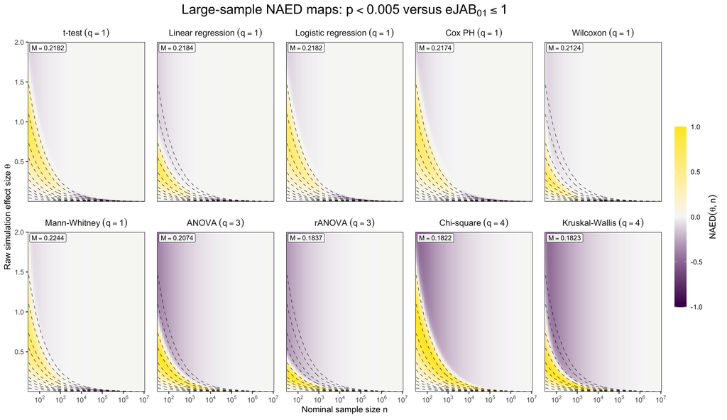

```r
p_vs_ejab <- plot_criticality_map(
  plot_data,
  "delta_p_minus_ejab",
  expression(
    "Large-sample NAED maps: " *
      p < 0.005 ~ "versus" ~ eJAB["01"] <= 1
  ),
  "01_ejab_vs_p005_all_10_tests.png",
  ncol = 5,
  height = 7.5
)
p_vs_ejab
```

## 2. eJAB versus $p<0.05$: all 10 tests

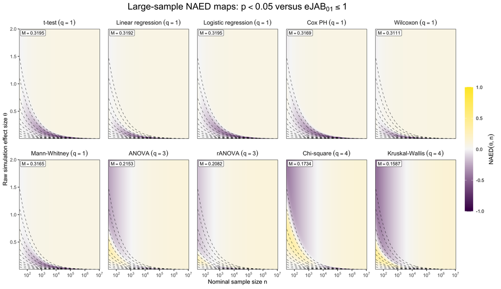

```r
p05_vs_ejab <- plot_criticality_map(
  plot_data,
  "delta_p05_minus_ejab",
  expression(
    "Large-sample NAED maps: " *
      p < 0.05 ~ "versus" ~ eJAB["01"] <= 1
  ),
  "02_ejab_vs_p05_all_10_tests.png",
  ncol = 5,
  height = 7.5
)
p05_vs_ejab
```

## 3. eJAB versus BIC BF: six parametric-likelihood tests

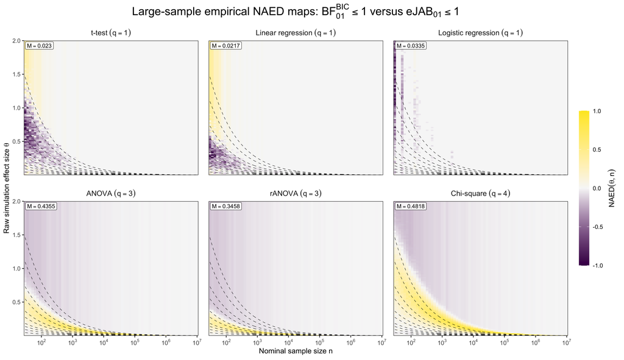

```r
bic_vs_ejab <- plot_criticality_map(
  empirical_bic_plot_data,
  "delta_bic_minus_ejab",
  expression(
    "Large-sample empirical NAED maps: " *
      BF["01"]^plain(BIC) <= 1 ~ "versus" ~ eJAB["01"] <= 1
  ),
  "02_ejab_vs_bic_bf01_six_parametric_tests.png",
  ncol = 3,
  height = 7.5,
  x_breaks = 2:7,
  x_labels = parse(text = paste0("10^", 2:7)),
  y_max = 2,
  y_breaks = c(0.5, 1, 1.5, 2)
)

bic_vs_ejab
```

## 4. eJAB versus TSBF: three chi-square table dimensions

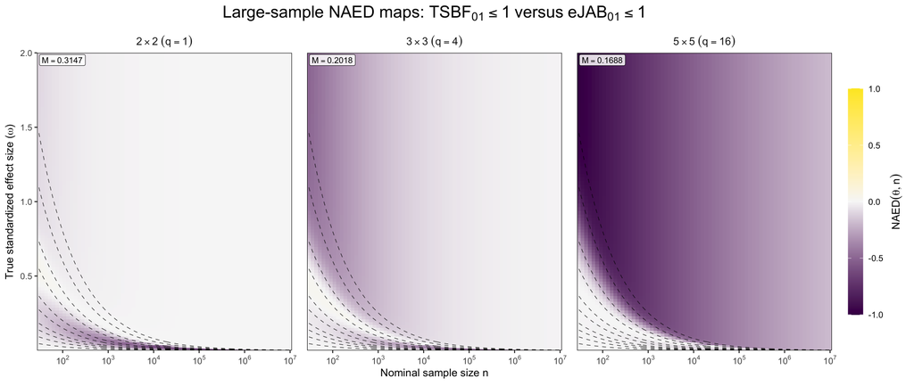

```r
tsbf_vs_ejab <- plot_criticality_map(
  tsbf_dimension_plot_data,
  "delta_tsbf_minus_ejab",
  expression(
    "Large-sample NAED maps: " *
      TSBF["01"] <= 1 ~ "versus" ~ eJAB["01"] <= 1
  ),
  "03_ejab_vs_tsbf01_three_table_sizes.png",
  ncol = 3,
  height = 5.5,
  y_label = expression(
    "True standardized effect size (" * omega * ")"
  )
)
tsbf_vs_ejab
```

## 5. Sensitivity analysis: TSBF using estimated effect size

The primary TSBF map above evaluates the BFF at the population effect size used to generate each risk cell. As a plug-in sensitivity analysis, this version estimates Cohen’s effect from each realized chi-square statistic:

$$\widehat\omega=\sqrt{\frac{X^2}{n}},\qquad
\widehat\tau^2=\frac{n}{q}\widehat\omega^2=\frac{X^2}{q}.$$

Consequently, the BFF depends on the observed $X^2$ both directly and through $\widehat\tau^2$. With the threshold $BF_{01}\leq1$, $X^2=0$ is an exact equality point with probability zero under the continuous chi-square distribution. For positive $X^2$, the BFF initially falls below the threshold and then crosses it from below. The risk calculation uses that positive upper crossing as the rejection boundary.

This plug-in calculation is useful for the requested sensitivity check, but it is an empirical-Bayes-style use of the test statistic rather than integration over uncertainty in $\omega$.

```r
estimated_omega_tsbf_critical_table <- chisq_dimensions |>
  transmute(
    table_label,
    q,
    positive_chisq_critical = unname(
      estimated_omega_tsbf_criticals[as.character(q)]
    ),
    alpha = pchisq(
      positive_chisq_critical,
      df = q,
      lower.tail = FALSE
    )
  )

write.csv(
  estimated_omega_tsbf_critical_table,
  file.path(output_dir, "estimated_omega_tsbf_critical_values.csv"),
  row.names = FALSE
)

kable(
  estimated_omega_tsbf_critical_table,
  digits = 6,
  caption = "Plug-in estimated-effect TSBF rejection boundaries"
)
```

Plug-in estimated-effect TSBF rejection boundaries

| table_label | q | positive_chisq_critical | alpha |
| --- | --- | --- | --- |
| 2 x 2 (q=1) | 1 | 2.393041 | 0.121876 |
| 3 x 3 (q=4) | 4 | 7.221455 | 0.124638 |
| 5 x 5 (q=16) | 16 | 25.757081 | 0.057544 |

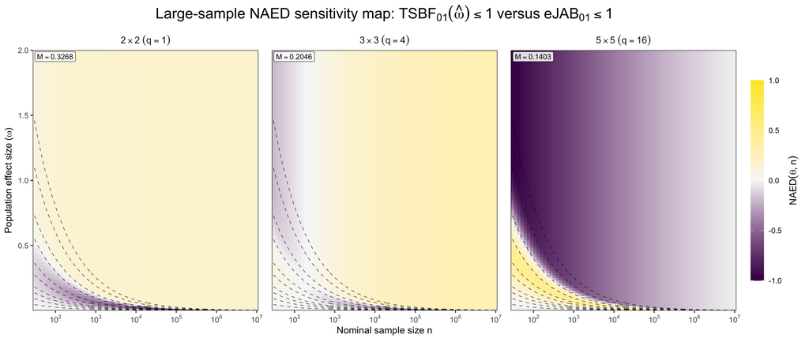

```r
tsbf_estimated_omega_vs_ejab <- plot_criticality_map(
  tsbf_estimated_omega_dimension_plot_data,
  "delta_tsbf_estimated_omega_minus_ejab",
  expression(
    "Large-sample NAED sensitivity map: " *
      TSBF["01"](hat(omega)) <= 1 ~ "versus" ~ eJAB["01"] <= 1
  ),
  "03b_ejab_vs_tsbf01_estimated_omega_three_table_sizes.png",
  ncol = 3,
  height = 5.5,
  y_label = expression(
    "Population effect size (" * omega * ")"
  )
)
tsbf_estimated_omega_vs_ejab
```

## Combined figure

```r
combined <- p_vs_ejab / p05_vs_ejab / bic_vs_ejab / tsbf_vs_ejab +
  plot_annotation(
    title = "Four normalized average error difference (NAED) comparisons for eJAB",
    theme = theme(plot.title = element_text(face = "bold", size = 16))
  )
combined
```

[figure not shown]

```r
ggsave(
  file.path(output_dir, "00_all_four_bayes_risk_comparisons.png"),
  combined,
  width = 17,
  height = 30,
  dpi = 300
)
```

## Manuscript figure

The manuscript combines the estimated-effect TSBF, prespecified-effect TSBF, and $p<0.05$ comparisons without changing their panelwise normalization.

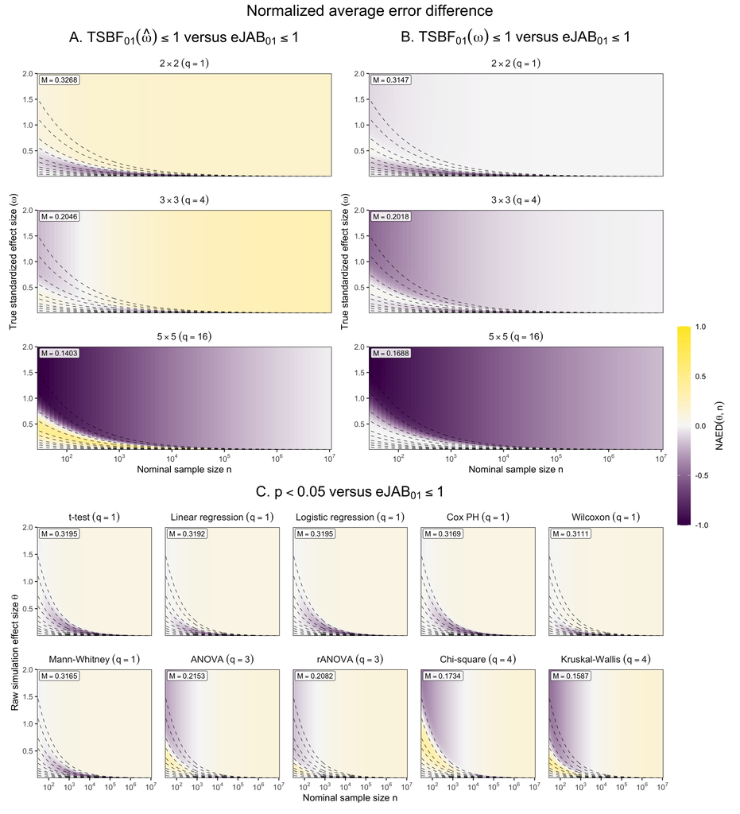

```r
manuscript_a <- tsbf_estimated_omega_vs_ejab +
  facet_wrap(~ facet_label, ncol = 1, labeller = label_parsed) +
  labs(
    title = expression(
      "A. " * TSBF["01"](hat(omega)) <= 1 ~ "versus" ~ eJAB["01"] <= 1
    ),
    y = expression("True standardized effect size (" * omega * ")")
  )
manuscript_b <- tsbf_vs_ejab +
  facet_wrap(~ facet_label, ncol = 1, labeller = label_parsed) +
  labs(title = expression(
    "B. " * TSBF["01"](omega) <= 1 ~ "versus" ~ eJAB["01"] <= 1
  ))
manuscript_c <- p05_vs_ejab +
  labs(title = expression(
    "C. " * p < 0.05 ~ "versus" ~ eJAB["01"] <= 1
  ))
manuscript_naed <- ((manuscript_a | manuscript_b) / manuscript_c) +
  plot_layout(heights = c(3, 2), guides = "collect") +
  plot_annotation(
    title = "Normalized average error difference",
    theme = theme(plot.title = element_text(hjust = 0.5, size = 18))
  )
manuscript_naed
```

```r
ggsave(
  file.path(output_dir, "05_manuscript_naed.png"),
  manuscript_naed,
  width = 12,
  height = 13.2,
  dpi = 300
)
```

# Focused chi-square comparison across table dimensions

This analysis directly addresses the comparison of $eJAB_{01}\leq1$ with:

1. $p<0.05$, and
2. $TSBF_{01}\leq1$, with the BFF evaluated at the true standardized effect size.

The columns correspond to $2\times2$, $3\times3$, and $5\times5$ independence tests, with $q=(R-1)(C-1)$ degrees of freedom. The common vertical axis is Cohen’s $w$, so the effect-size scale is comparable across table dimensions. Under the noncentral chi-square approximation,

$$X^2\mid H_0\sim\chi_q^2,\qquad
X^2\mid w\sim\chi_q^2(nw^2).$$

Following Eqs. (6.5) and (6.6) of `Bayes_factor_function (1).pdf`, the chi-square BFF is

$$BFF_{10}(X^2\mid\tau^2)
=(1+\tau^2)^{-q/2-1}
\left\{1+\frac{\tau^2X^2}{q(1+\tau^2)}\right\}
\exp\left\{\frac{\tau^2X^2}{2(1+\tau^2)}\right\},
\qquad
\tau_\omega^2=\frac{n}{q}\omega^2.$$

The BFF is evaluated at the true standardized effect, so the implementation sets $\tau^2=(n/q)w^2$. The risk calculations use equal prior model probabilities and equal error costs:

$$R_d(n,w)=\frac12\{\alpha_d(n,w)+1-\operatorname{power}_d(n,w)\}.$$

The contingency-table generator below implements the checkerboard probability perturbation used for these comparisons. For an $R\times C$ table, there are $4\lfloor R/2\rfloor\lfloor C/2\rfloor$ perturbed cells. With

$$\delta=
\frac{0.5w}{
\sqrt{RC\lfloor R/2\rfloor\lfloor C/2\rfloor}},$$

the resulting population Cohen’s effect satisfies

$$\sum_{i,j}\frac{(p_{ij}-1/(RC))^2}{1/(RC)}=w^2.$$

Thus, the noncentral chi-square risk engine below is the large-sample counterpart of this exact data-generating process. This probability construction requires

$$w\leq 2\sqrt{
\frac{\lfloor R/2\rfloor\lfloor C/2\rfloor}{RC}
}.$$

The maxima are $1$, $2/3$, and $0.8$ for the $2\times2$, $3\times3$, and $5\times5$ designs, respectively. These bounds apply only to this particular checkerboard construction. The noncentral chi-square risk calculation depends on $(q,n,w)$, rather than on that construction, so the plots use the broader common range $0\leq w\leq2$. Values above a design’s attainable maximum should therefore be interpreted as theoretical noncentral chi-square extrapolations rather than results generated by a contingency table from that design.

```r
chisq_probabilities_from_omega <- function(R, C, omega = 0) {
  stopifnot(
    length(R) == 1, length(C) == 1, length(omega) == 1,
    is.finite(R), is.finite(C), is.finite(omega),
    R >= 2, C >= 2, R == as.integer(R), C == as.integer(C),
    omega >= 0
  )

  K <- R * C
  active_blocks <- floor(R / 2) * floor(C / 2)
  delta <- 0.5 * omega / sqrt(K * active_blocks)

  perturbation <- outer(
    seq_len(R),
    seq_len(C),
    function(i, j) (-1)^(i + j)
  )
  if (R %% 2 == 1) perturbation[R, ] <- 0
  if (C %% 2 == 1) perturbation[, C] <- 0

  probabilities <- matrix(1 / K, nrow = R, ncol = C) +
    delta * perturbation

  probability_tolerance <- sqrt(.Machine$double.eps)
  if (
    any(probabilities < -probability_tolerance) ||
      any(probabilities > 1 + probability_tolerance)
  ) {
    stop("omega produces invalid cell probabilities.")
  }
  pmin(pmax(probabilities, 0), 1)
}

simData6 <- function(
    size, R, C, omega = 0,
    simType = c("jointMulti", "indepMulti")) {
  simType <- match.arg(simType)
  if (
    length(size) != 1 || !is.finite(size) ||
      size < 1 || size != as.integer(size)
  ) {
    stop("size must be a positive integer.")
  }

  prob_H1 <- chisq_probabilities_from_omega(R, C, omega)

  if (simType == "jointMulti") {
    draw <- rmultinom(1, size = size, prob = as.vector(prob_H1))
    matrix(draw, nrow = R, ncol = C)
  } else {
    if (size %% R != 0) {
      stop("size must be divisible by R for balanced fixed row margins.")
    }
    row_size <- size / R
    t(vapply(
      seq_len(R),
      function(i) {
        as.vector(rmultinom(1, size = row_size, prob = prob_H1[i, ]))
      },
      numeric(C)
    ))
  }
}

chisq_design_validation <- chisq_dimensions |>
  select(rows, columns, table_label, q) |>
  crossing(omega = c(0.1, 0.3, 0.5, 0.65)) |>
  mutate(
    probabilities = pmap(
      list(rows, columns, omega),
      chisq_probabilities_from_omega
    ),
    recovered_omega = map_dbl(
      probabilities,
      function(p) {
        p0 <- 1 / length(p)
        sqrt(sum((p - p0)^2 / p0))
      }
    ),
    maximum_row_margin_error = map_dbl(
      probabilities,
      ~ max(abs(rowSums(.x) - 1 / nrow(.x)))
    ),
    maximum_column_margin_error = map_dbl(
      probabilities,
      ~ max(abs(colSums(.x) - 1 / ncol(.x)))
    )
  ) |>
  select(-probabilities)

stopifnot(
  max(abs(
    chisq_design_validation$recovered_omega -
      chisq_design_validation$omega
  )) < 1e-12,
  max(chisq_design_validation$maximum_row_margin_error) < 1e-12,
  max(chisq_design_validation$maximum_column_margin_error) < 1e-12,
  sum(simData6(120, 3, 3, 0.3, "jointMulti")) == 120,
  all(rowSums(
    simData6(120, 3, 3, 0.3, "indepMulti")
  ) == 40)
)

kable(
  chisq_design_validation,
  digits = 12,
  caption = "Validation of the contingency-table effect-size construction"
)
```

Validation of the contingency-table effect-size construction

| rows | columns | table_label | q | omega | recovered_omega | maximum_row_margin_error | maximum_column_margin_error |
| --- | --- | --- | --- | --- | --- | --- | --- |
| 2 | 2 | 2 x 2 (q=1) | 1 | 0.10 | 0.10 | 0 | 0 |
| 2 | 2 | 2 x 2 (q=1) | 1 | 0.30 | 0.30 | 0 | 0 |
| 2 | 2 | 2 x 2 (q=1) | 1 | 0.50 | 0.50 | 0 | 0 |
| 2 | 2 | 2 x 2 (q=1) | 1 | 0.65 | 0.65 | 0 | 0 |
| 3 | 3 | 3 x 3 (q=4) | 4 | 0.10 | 0.10 | 0 | 0 |
| 3 | 3 | 3 x 3 (q=4) | 4 | 0.30 | 0.30 | 0 | 0 |
| 3 | 3 | 3 x 3 (q=4) | 4 | 0.50 | 0.50 | 0 | 0 |
| 3 | 3 | 3 x 3 (q=4) | 4 | 0.65 | 0.65 | 0 | 0 |
| 5 | 5 | 5 x 5 (q=16) | 16 | 0.10 | 0.10 | 0 | 0 |
| 5 | 5 | 5 x 5 (q=16) | 16 | 0.30 | 0.30 | 0 | 0 |
| 5 | 5 | 5 x 5 (q=16) | 16 | 0.50 | 0.50 | 0 | 0 |
| 5 | 5 | 5 x 5 (q=16) | 16 | 0.65 | 0.65 | 0 | 0 |

```r
chisq_dimension_risk_file <- file.path(
  output_dir, "chisq_dimensions_risk_grid.csv"
)
write.csv(
  chisq_dimension_risk,
  chisq_dimension_risk_file,
  row.names = FALSE
)

chisq_pattern_agreement <- chisq_dimension_risk |>
  group_by(rows, columns, table_label, q) |>
  summarise(
    grid_cells = n(),
    same_lower_risk_rule = mean(
      sign(delta_p05_minus_ejab) == sign(delta_tsbf_minus_ejab)
    ),
    both_favor_ejab = mean(
      delta_p05_minus_ejab > 0 & delta_tsbf_minus_ejab > 0
    ),
    both_favor_reference = mean(
      delta_p05_minus_ejab < 0 & delta_tsbf_minus_ejab < 0
    ),
    p05_only_favors_ejab = mean(
      delta_p05_minus_ejab > 0 & delta_tsbf_minus_ejab < 0
    ),
    tsbf_only_favors_ejab = mean(
      delta_p05_minus_ejab < 0 & delta_tsbf_minus_ejab > 0
    ),
    .groups = "drop"
  )

write.csv(
  chisq_pattern_agreement,
  file.path(output_dir, "chisq_dimensions_pattern_agreement.csv"),
  row.names = FALSE
)

kable(
  chisq_pattern_agreement,
  digits = 3,
  caption = "Agreement between the two eJAB risk-comparison patterns"
)
```

Agreement between the two eJAB risk-comparison patterns

| rows | columns | table_label | q | grid_cells | same_lower_risk_rule | both_favor_ejab | both_favor_reference | p05_only_favors_ejab | tsbf_only_favors_ejab |
| --- | --- | --- | --- | --- | --- | --- | --- | --- | --- |
| 2 | 2 | 2 x 2 (q=1) | 1 | 7280 | 0.197 | 0.033 | 0.163 | 0.799 | 0.004 |
| 3 | 3 | 3 x 3 (q=4) | 4 | 7280 | 0.366 | 0.017 | 0.349 | 0.634 | 0.000 |
| 5 | 5 | 5 x 5 (q=16) | 16 | 7280 | 0.844 | 0.007 | 0.837 | 0.156 | 0.000 |

Each panel below starts with the raw average error difference $\Delta A=A_{\mathrm{reference}}-A_{eJAB}$, then divides by that panel’s largest absolute raw difference:

$$\operatorname{NAED}(\theta,n)=\frac{\Delta A(\theta,n)}{M},
\qquad M=\max_{(\theta,n)\in\mathcal G}|\Delta A(\theta,n)|,
\quad \theta=w.$$

All panels therefore span the common scale $[-1,1]$, while the annotation in each panel reports the raw maximum $M$ used as its divisor. Positive/yellow values favor eJAB; negative/purple values favor the rule named in that row. No average error differences are clipped.

```r
chisq_x_bounds <- cell_boundaries(log10(dense_n_grid))
chisq_w_bounds <- cell_boundaries(
  chisq_w_grid, lower = 0, upper = chisq_w_max
)

chisq_dimension_plot_data <- chisq_dimension_risk |>
  select(
    rows, columns, table_label, table_plot_label, q, n, w,
    delta_p05_minus_ejab, delta_tsbf_minus_ejab
  ) |>
  pivot_longer(
    cols = starts_with("delta_"),
    names_to = "comparison",
    values_to = "risk_advantage"
  ) |>
  mutate(
    log10_n = log10(n),
    table_label = factor(
      table_label,
      levels = chisq_dimensions$table_label
    ),
    comparison = factor(
      comparison,
      levels = c(
        "delta_p05_minus_ejab",
        "delta_tsbf_minus_ejab"
      ),
      labels = c(
        "p < 0.05 versus eJAB",
        "TSBF(true w) versus eJAB"
      )
    ),
    comparison_plot_label = factor(
      comparison,
      levels = c(
        "p < 0.05 versus eJAB",
        "TSBF(true w) versus eJAB"
      ),
      labels = c(
        "italic(p) < 0.05~'versus'~eJAB['01'] <= 1",
        "TSBF['01'](omega) <= 1~'versus'~eJAB['01'] <= 1"
      )
    ),
    table_plot_label = factor(
      table_plot_label,
      levels = chisq_dimensions$table_plot_label
    )
  ) |>
  left_join(
    chisq_x_bounds |>
      transmute(log10_n = center, xmin = lower, xmax = upper),
    by = "log10_n"
  ) |>
  left_join(
    chisq_w_bounds |>
      transmute(w = center, ymin = lower, ymax = upper),
    by = "w"
  ) |>
  group_by(comparison, table_label) |>
  mutate(
    panel_max_abs_risk_difference = max(
      abs(risk_advantage), na.rm = TRUE
    ),
    scaled_risk_advantage =
      risk_advantage / panel_max_abs_risk_difference
  ) |>
  ungroup()

chisq_panel_scaling_factors <- chisq_dimension_plot_data |>
  distinct(
    comparison,
    table_label,
    panel_max_abs_risk_difference
  ) |>
  arrange(comparison, table_label)

write.csv(
  chisq_panel_scaling_factors,
  file.path(
    output_dir,
    "chisq_dimensions_panel_scaling_factors.csv"
  ),
  row.names = FALSE
)

kable(
  chisq_panel_scaling_factors,
  digits = 6,
  caption = "Panel-specific maximum absolute raw average error differences (M)"
)
```

Panel-specific maximum absolute raw average error differences (M)

| comparison | table_label | panel_max_abs_risk_difference |
| --- | --- | --- |
| p < 0.05 versus eJAB | 2 x 2 (q=1) | 0.319229 |
| p < 0.05 versus eJAB | 3 x 3 (q=4) | 0.173896 |
| p < 0.05 versus eJAB | 5 x 5 (q=16) | 0.144044 |
| TSBF(true w) versus eJAB | 2 x 2 (q=1) | 0.314733 |
| TSBF(true w) versus eJAB | 3 x 3 (q=4) | 0.201794 |
| TSBF(true w) versus eJAB | 5 x 5 (q=16) | 0.168765 |

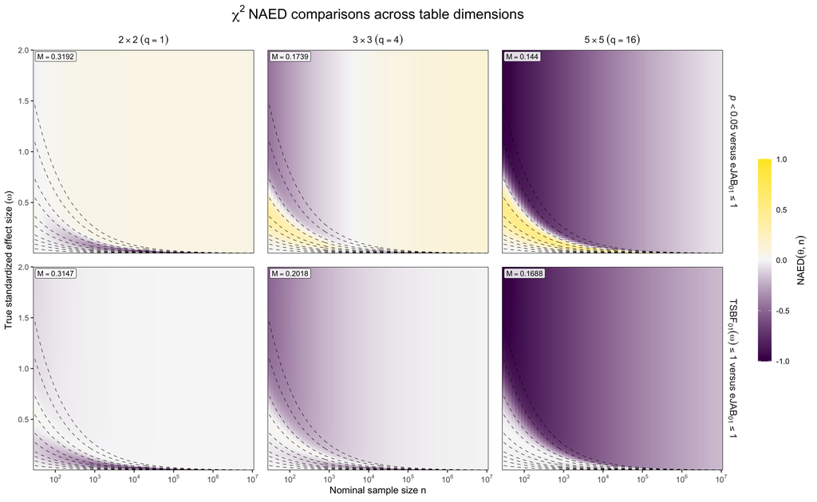

```r
chisq_panel_annotations <- chisq_panel_scaling_factors |>
  left_join(
    chisq_dimension_plot_data |>
      distinct(
        comparison, table_label,
        comparison_plot_label, table_plot_label
      ),
    by = c("comparison", "table_label")
  ) |>
  mutate(
    annotation = sprintf(
      "M == %.4f",
      panel_max_abs_risk_difference
    )
  )

chisq_local_contours <- local_alternative_contours(
  dense_n_grid,
  chisq_w_grid
)

chisq_dimension_risk_plot <- ggplot(
  chisq_dimension_plot_data,
  aes(
    xmin = xmin, xmax = xmax,
    ymin = ymin, ymax = ymax,
    fill = scaled_risk_advantage
  )
) +
  geom_rect() +
  geom_line(
    data = chisq_local_contours,
    aes(x = log10_n, y = theta, group = c_value),
    inherit.aes = FALSE,
    color = "black",
    linetype = "dashed",
    linewidth = 0.3,
    alpha = 0.75
  ) +
  geom_label(
    data = chisq_panel_annotations,
    aes(x = -Inf, y = Inf, label = annotation),
    inherit.aes = FALSE,
    hjust = -0.05,
    vjust = 1.15,
    size = 3,
    linewidth = 0.2,
    parse = TRUE,
    fill = scales::alpha("white", 0.85)
  ) +
  facet_grid(
    comparison_plot_label ~ table_plot_label,
    labeller = label_parsed
  ) +
  scale_x_continuous(
    breaks = 2:7,
    labels = parse(text = paste0("10^", 2:7)),
    expand = c(0, 0)
  ) +
  scale_y_continuous(
    breaks = seq(0.5, chisq_w_max, by = 0.5),
    limits = c(0, chisq_w_max),
    expand = c(0, 0)
  ) +
  scale_fill_gradient2(
    low = "#440154",
    mid = "#F7F7F7",
    high = "#FDE725",
    midpoint = 0,
    limits = c(-1, 1),
    breaks = c(-1, -0.5, 0, 0.5, 1),
    name = expression(plain(NAED)(theta, n))
  ) +
  labs(
    title = expression(chi^2~"NAED comparisons across table dimensions"),
    x = expression("Nominal sample size " * n),
    y = expression("True standardized effect size (" * omega * ")")
  ) +
  guides(
    fill = guide_colorbar(
      title.position = "right",
      barwidth = grid::unit(0.55, "cm"),
      barheight = grid::unit(8.2, "cm")
    )
  ) +
  theme_bw(base_size = 11) +
  theme(
    panel.grid = element_blank(),
    panel.border = element_rect(color = "black", linewidth = 0.45),
    legend.position = "right",
    legend.title = element_text(angle = 90, hjust = 0.5),
    strip.background = element_blank(),
    strip.text = element_text(size = 11),
    plot.title = element_text(hjust = 0.5, size = 16),
    axis.text.x = element_text(size = 9),
    panel.spacing = grid::unit(0.55, "cm")
  )

chisq_dimension_risk_plot
```

```r
ggsave(
  file.path(
    output_dir,
    "04_chisq_dimensions_ejab_vs_p05_and_tsbf.png"
  ),
  chisq_dimension_risk_plot,
  width = 15,
  height = 8,
  dpi = 300
)
```

# Reproducibility

```r
settings <- tibble(
  setting = c(
    "Seed",
    "Null replicates per test/sample-size cell",
    "Alternative replicates per effect-size cell",
    "BIC null replicates per test/sample-size cell",
    "BIC alternative replicates per effect-size cell",
    "Workers",
    "eJAB/BIC/TSBF BF01 threshold",
    "Classical p-value threshold (stringent)",
    "Classical p-value threshold (conventional)",
    "Simulation cache",
    "Dense empirical BIC cache"
  ),
  value = c(
    params$seed,
    params$null_reps,
    params$alt_reps,
    params$bic_null_reps,
    params$bic_alt_reps,
    params$workers,
    bf01_threshold,
    p_threshold,
    p05_threshold,
    simulation_file,
    bic_simulation_file
  )
)
kable(settings)
```

| setting | value |
| --- | --- |
| Seed | 20260724 |
| Null replicates per test/sample-size cell | 2000 |
| Alternative replicates per effect-size cell | 500 |
| BIC null replicates per test/sample-size cell | 2000 |
| BIC alternative replicates per effect-size cell | 400 |
| Workers | 4 |
| eJAB/BIC/TSBF BF01 threshold | 1 |
| Classical p-value threshold (stringent) | 0.005 |
| Classical p-value threshold (conventional) | 0.05 |
| Simulation cache | bayes_risk_outputs/revised_three_comparisons/bayes_risk_simulation.rds |
| Dense empirical BIC cache | bayes_risk_outputs/revised_three_comparisons/large_sample_empirical_bic_simulation.rds |